# Chemical kinetics

## Simple reactions

Here, I consider reactions of the following type: $$ \text{A} \overset{k}{\longrightarrow} \text{B} $$

In this case, we can write the equation for the rate of the reaction as $\displaystyle\frac{d[\text{A}]}{dt} = -k[\text{A}]^n$, where $n$ is the reaction order with respect to $\text{A}$ and can be $0, 1$ or $2$. By solving this equation for $[\text{A}]_0 = 0.1 \text{M}$, we can obtain the reagent concentration as a function of time. Knowing that $[\text{A}]_0 = [\text{A}] + [\text{B}]$ or $\displaystyle\frac{d[\text{B}]}{dt} = k[\text{A}]^n$, we can find the concentration of the product versus time.

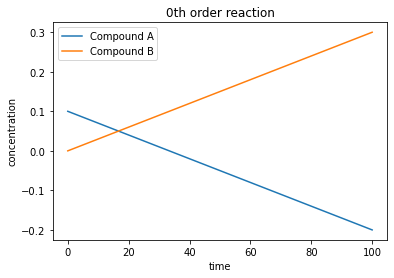

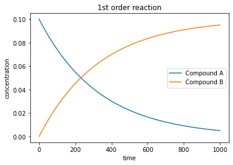

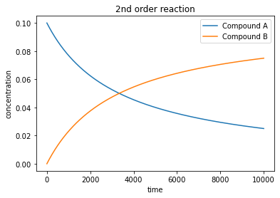

```python
import numpy as np
import matplotlib.pyplot as plt
from scipy.integrate import  solve_ivp

rateConst = 0.003
initConc = 0.1
tEnd = 100
tEval = np.linspace(0, tEnd, 1000)

def simpleFunc0(t, y):
    deriv0 = [0, 0]
    deriv0[0] = -rateConst
    deriv0[1] = rateConst

    return deriv0

def simpleFunc1(t, y):
    deriv1 = [0, 0]
    deriv1[0] = -rateConst * y[0]
    deriv1[1] = rateConst * y[0]

    return deriv1

def simpleFunc2(t, y):
    deriv2 = [0, 0]
    deriv2[0] = -rateConst * (y[0] ** 2)
    deriv2[1] = rateConst * (y[0] ** 2)

    return deriv2

solSimple0 = solve_ivp(simpleFunc0, (0, tEnd), [initConc, 0], t_eval = tEval)

plt.plot(solSimple0.t, solSimple0.y[0], solSimple0.t, solSimple0.y[1])
plt.title('0th order reaction')
plt.xlabel('time')
plt.ylabel('concentration')
plt.legend(('Compound A', 'Compound B'))
plt.show()


# for the 1st order reaction, t=100 is not enough to see the graph shape. It appears linear
tEnd = 1000
tEval = np.linspace(0, tEnd, 1000)

solSimple1 = solve_ivp(simpleFunc1, (0, tEnd), [initConc, 0], t_eval = tEval)

plt.plot(solSimple1.t, solSimple1.y[0], solSimple1.t, solSimple1.y[1])
plt.title('1st order reaction')
plt.xlabel('time')
plt.ylabel('concentration')
plt.legend(('Compound A', 'Compound B'))
plt.show()


# for the 1st order reaction, t=1000 is not enough to see the graph shape. It appears linear
tEnd = 10000
tEval = np.linspace(0, tEnd, 1000)

solSimple2 = solve_ivp(simpleFunc2, (0, tEnd), [initConc, 0], t_eval = tEval)

plt.plot(solSimple2.t, solSimple2.y[0], solSimple2.t, solSimple2.y[1])
plt.title('2nd order reaction')
plt.xlabel('time')
plt.ylabel('concentration')
plt.legend(('Compound A', 'Compound B'))
plt.show()
```

## Steady state approximation

$$ \text{A} \overset{k_1}{\longrightarrow} \text{B} \overset{k_2}{\longrightarrow} \text{C} $$

In the reaction above, I take that $\displaystyle\frac{d[\text{A}]}{dt} = -k_1 [\text{A}]$, $\displaystyle\frac{d[\text{B}]}{dt} = -k_2 [\text{B}] + k_1 [\text{A}]$, and $\displaystyle\frac{d[\text{C}]}{dt} = k_2 [\text{B}]$. In any given point in time $[\text{A}]_0 = [\text{A}] + [\text{B}] + [\text{C}]$.

There can be two cases: when $k_2 >> k_1$ and when this is not true. When it is true, we can use Steady State approximation — take concentration of $B$ as a constant. With this simulation, it is possible to assess whether this is a sensible approximation.

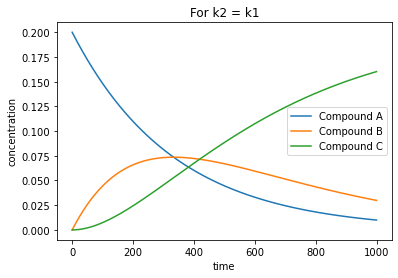

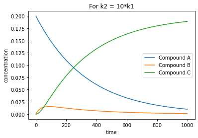

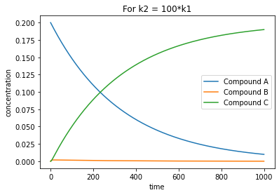

```python
k1 = 0.003
k2 = 0.003
initConc = 0.2
tEnd = 1000
tEval = np.linspace(0, tEnd, 1000)

def steadyFunc(t, y):
    deriv = [0, 0, 0]
    deriv[0] = -k1 * y[0]
    deriv[1] = -k2 * y[1] + k1 * y[0]
    deriv[2] = k2 * y[1]

    return deriv

solSteady1 = solve_ivp(steadyFunc, (0, tEnd), [initConc, 0, 0], t_eval = tEval)

plt.plot(solSteady1.t, solSteady1.y[0], solSteady1.t, solSteady1.y[1], solSteady1.t, solSteady1.y[2])
plt.legend(('Compound A', 'Compound B', 'Compound C'))
plt.xlabel('time')
plt.ylabel('concentration')
plt.title('For k2 = k1')
plt.show()

k2 = 0.03
solSteady2 = solve_ivp(steadyFunc, (0, tEnd), [initConc, 0, 0], t_eval = tEval)

plt.plot(solSteady2.t, solSteady2.y[0], solSteady2.t, solSteady2.y[1], solSteady2.t, solSteady2.y[2])
plt.legend(('Compound A', 'Compound B', 'Compound C'))
plt.xlabel('time')
plt.ylabel('concentration')
plt.title('For k2 = 10*k1')
plt.show()

k2 = 0.3
solSteady3 = solve_ivp(steadyFunc, (0, tEnd), [initConc, 0, 0], t_eval = tEval)

plt.plot(solSteady3.t, solSteady3.y[0], solSteady3.t, solSteady3.y[1], solSteady3.t, solSteady3.y[2])
plt.legend(('Compound A', 'Compound B', 'Compound C'))
plt.xlabel('time')
plt.ylabel('concentration')
plt.title('For k2 = 100*k1')
plt.show()
```

## Pre-equilibrium approximation

$$ \text{A} \overset{k_1}{ \underset{k_{-1}}{\rightleftharpoons} } \text{B} \overset{k_2}{\rightarrow} \text{C} $$

In the above reaction, I take that $\displaystyle\frac{d[\text{A}]}{dt} = -k_1 [\text{A}] + k_{-1}[\text{B}]$, $\displaystyle\frac{d[\text{B}]}{dt} = k_1 [\text{A}] - k_{2}[\text{B}] - k_{-1}[\text{B}]$ and $\displaystyle\frac{d[\text{C}]}{dt} = k_2 [\text{B}]$.

When $k_1, k_{-1} >> k_2$, we can use pre-equilibrium approximation and say that $\displaystyle\frac{[\text{B}]}{[\text{A}]} \approx const = \frac{k_1}{k_{-1}}$.

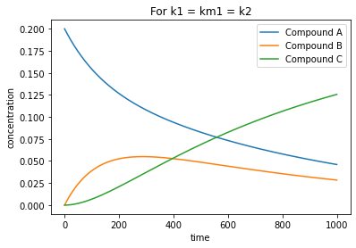

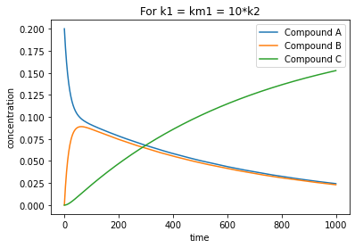

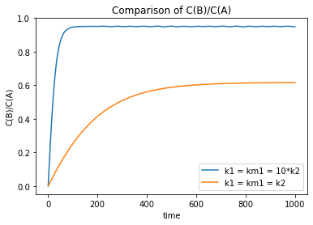

```python
k1 = 0.003
km1 = 0.003
k2 = 0.003
initConc = 0.2
tEnd = 1000
tEval = np.linspace(0, tEnd, 1000)

def equilFunc(t, y):
    deriv = [0, 0, 0]
    deriv[0] = -k1 * y[0] + km1 * y[1]
    deriv[1] = -k2 * y[1] + k1 * y[0] - km1 * y[1]
    deriv[2] = k2 * y[1]

    return deriv

solEquil1 = solve_ivp(equilFunc, (0, tEnd), [initConc, 0, 0], t_eval = tEval)

plt.plot(solEquil1.t, solEquil1.y[0], solEquil1.t, solEquil1.y[1], solEquil1.t, solEquil1.y[2])
plt.legend(('Compound A', 'Compound B', 'Compound C'))
plt.xlabel('time')
plt.ylabel('concentration')
plt.title('For k1 = km1 = k2')
plt.show()


k1 = 0.03
km1 = 0.03
solEquil2 = solve_ivp(equilFunc, (0, tEnd), [initConc, 0, 0], t_eval = tEval)

plt.plot(solEquil2.t, solEquil2.y[0], solEquil2.t, solEquil2.y[1], solEquil2.t, solEquil2.y[2])
plt.legend(('Compound A', 'Compound B', 'Compound C'))
plt.xlabel('time')
plt.ylabel('concentration')
plt.title('For k1 = km1 = 10*k2')
plt.show()

plt.plot(solEquil2.t, solEquil2.y[1]/solEquil2.y[0], solEquil1.t, solEquil1.y[1]/solEquil1.y[0])
plt.legend(('k1 = km1 = 10*k2', 'k1 = km1 = k2'))
plt.xlabel('time')
plt.ylabel('C(B)/C(A)')
plt.title('Comparison of C(B)/C(A)')
plt.show()
```

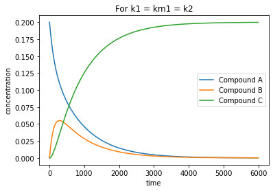

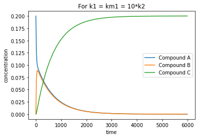

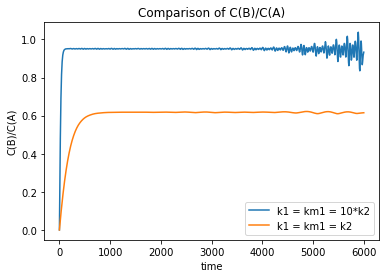

```python
tEnd2 = 6000
k1 = 0.003
km1 = 0.003
tEval = np.linspace(0, tEnd2, 1000)

solEquil3 = solve_ivp(equilFunc, (0, tEnd2), [initConc, 0, 0], t_eval = tEval)

plt.plot(solEquil3.t, solEquil3.y[0], solEquil3.t, solEquil3.y[1], solEquil3.t, solEquil3.y[2])
plt.legend(('Compound A', 'Compound B', 'Compound C'))
plt.xlabel('time')
plt.ylabel('concentration')
plt.title('For k1 = km1 = k2')
plt.show()


k1 = 0.03
km1 = 0.03
solEquil4 = solve_ivp(equilFunc, (0, tEnd2), [initConc, 0, 0], t_eval = tEval)

plt.plot(solEquil4.t, solEquil4.y[0], solEquil4.t, solEquil4.y[1], solEquil4.t, solEquil4.y[2])
plt.legend(('Compound A', 'Compound B', 'Compound C'))
plt.xlabel('time')
plt.ylabel('concentration')
plt.title('For k1 = km1 = 10*k2')
plt.show()

plt.plot(solEquil4.t, solEquil4.y[1]/solEquil4.y[0], solEquil3.t, solEquil3.y[1]/solEquil3.y[0])
plt.legend(('k1 = km1 = 10*k2', 'k1 = km1 = k2'))
plt.xlabel('time')
plt.ylabel('C(B)/C(A)')
plt.title('Comparison of C(B)/C(A)')
plt.show()
```